# Dynamic Network Visualizations with ndtv

Steve McDonald

2024-11-12

## Dynamic Network Visualizations

What is more fun than network visualization? Dynamic network visualization!

Most of the early sources of network data were based on time slices, which lend themselves well to static representations. However, we know that, in most instances, network relationships are constantly changing. Increasingly we have new sources of dynamic network data to go along with new tools to visualize changes over time. Here I present an example of one such tool in R: ndtv. For this tutorial, I have adapted and expanded on Skye Bender-deMoll’s excellent [workshop materials](https://statnet.org/workshop-ndtv/ndtv_workshop.html), which you should view for more information about the package and procedures.

Let’s get started by installing the relevant R packages.

```r
library(ndtv)
library(tsna)
```

The ndtv package uses statnet network objects. So be sure to convert any igraph objects to network objects using intergraph.

## Wheel example

We’ll begin by creating an empty network with 10 vertices.

```r
(wheel <- network.initialize(10))
```

```
##  Network attributes:
##   vertices = 10
##   directed = TRUE
##   hyper = FALSE
##   loops = FALSE
##   multiple = FALSE
##   bipartite = FALSE
##   total edges= 0
##     missing edges= 0
##     non-missing edges= 0
##
##  Vertex attribute names:
##     vertex.names
##
## No edge attributes
```

Now add a series of edges to the graph, while including time stamps for their onset.

```r
add.edges.active(wheel,tail=1:9,head=c(2:9,1),onset=1:9, terminus=11)
add.edges.active(wheel,tail=10,head=c(1:9),onset=10, terminus=12)
```

Let’s take a closer look at the data.

```r
as.data.frame(wheel)
```

```
##    onset terminus tail head onset.censored terminus.censored duration edge.id
## 1      1       11    1    2          FALSE             FALSE       10       1
## 2      2       11    2    3          FALSE             FALSE        9       2
## 3      3       11    3    4          FALSE             FALSE        8       3
## 4      4       11    4    5          FALSE             FALSE        7       4
## 5      5       11    5    6          FALSE             FALSE        6       5
## 6      6       11    6    7          FALSE             FALSE        5       6
## 7      7       11    7    8          FALSE             FALSE        4       7
## 8      8       11    8    9          FALSE             FALSE        3       8
## 9      9       11    9    1          FALSE             FALSE        2       9
## 10    10       12   10    1          FALSE             FALSE        2      10
## 11    10       12   10    2          FALSE             FALSE        2      11
## 12    10       12   10    3          FALSE             FALSE        2      12
## 13    10       12   10    4          FALSE             FALSE        2      13
## 14    10       12   10    5          FALSE             FALSE        2      14
## 15    10       12   10    6          FALSE             FALSE        2      15
## 16    10       12   10    7          FALSE             FALSE        2      16
## 17    10       12   10    8          FALSE             FALSE        2      17
## 18    10       12   10    9          FALSE             FALSE        2      18
```

Each row represents an edge. The onset indicate the timepoint when the edge emerges and the terminus shows when the edge dissolves. Tail tells you the node number that sends the tie and head is the node that receives the tie. Duration is the amount of time that the tie appears (terminus minus onset). Finally, we have an id number for each edge.

Now let’s plot out the network. The first graph shows all of the edges at once. The second shows what the edges look like at time 1. The third shows all edges that appeared between time 1 and time 5.

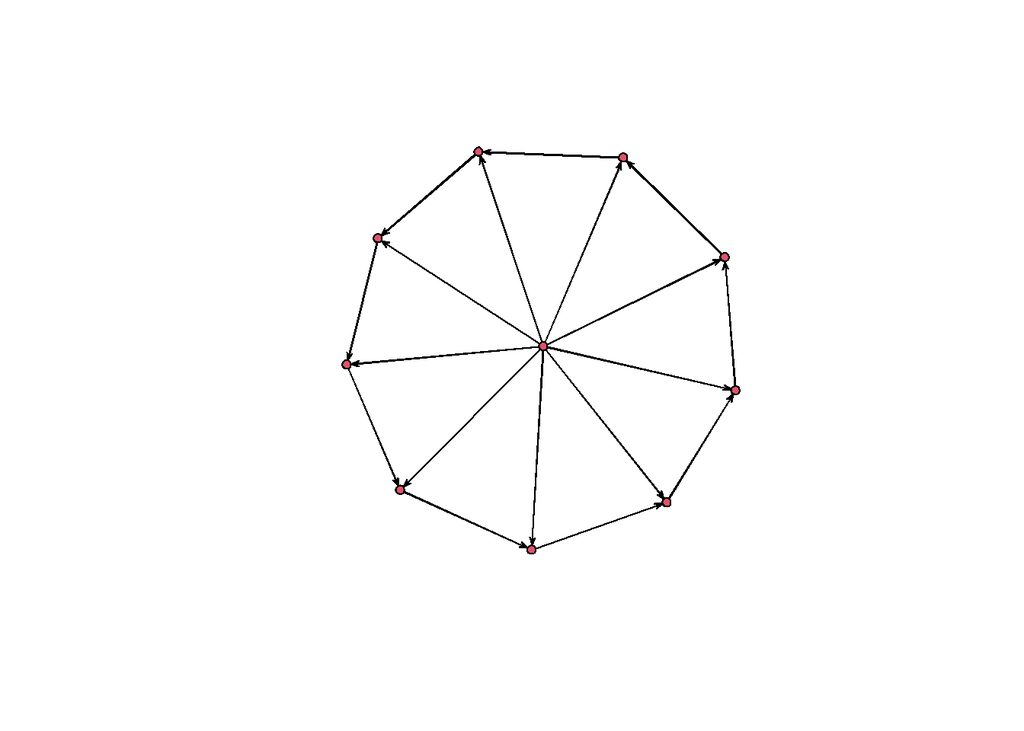

```r
plot(wheel)
```

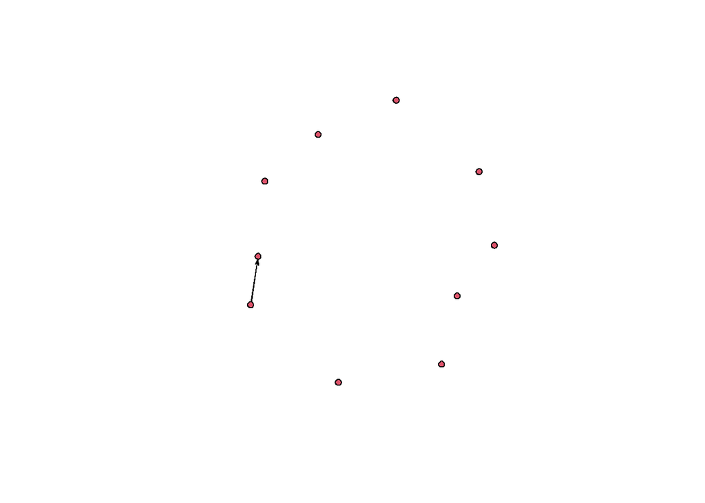

```r
plot(network.extract(wheel,at=1))
```

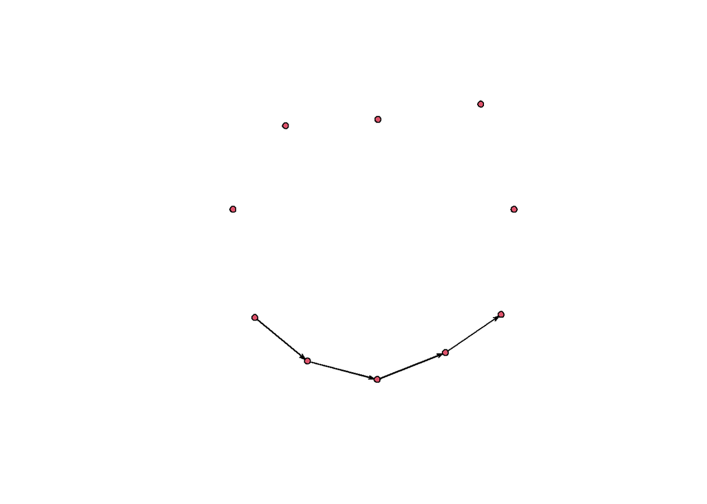

```r
plot(network.extract(wheel,onset=1,terminus=5))
```

Now let’s create a network movie to show the emergence of these ties over time.

```r
render.d3movie(wheel,output.mode = 'htmlWidget')
```

```
## slice parameters:
##   start:1
##   end:12
##   interval:1
##   aggregate.dur:1
##   rule:latest
```

[interactive chart not shown]

## Real-world dynamic networks

The above example presents simulated network data. How might these visualizations be applied to real-world networks? For this, I use the classic Newcomb Fraternity study, which examined the friendships between fraternity members at the University of Michigan over the course of the fall semester in 1956. These students provided weekly rankings of their friendships over this period. I recoded these numbers so that each tie represents a top-three friendship nomination during each time period. Note that these data are directed, in that student A might include student B in their top-3, but student B might not.

Let’s load the data. Then we can inspect the frat network object (frat_n).

```r
load("frat_graphs.rda")
head(frat_n)
```

```
## $frat0
##  Network attributes:
##   vertices = 17
##   directed = TRUE
##   hyper = FALSE
##   loops = FALSE
##   multiple = FALSE
##   bipartite = FALSE
##   total edges= 51
##     missing edges= 0
##     non-missing edges= 51
##
##  Vertex attribute names:
##     vertex.names
##
## No edge attributes
##
## $frat1
##  Network attributes:
##   vertices = 17
##   directed = TRUE
##   hyper = FALSE
##   loops = FALSE
##   multiple = FALSE
##   bipartite = FALSE
##   total edges= 51
##     missing edges= 0
##     non-missing edges= 51
##
##  Vertex attribute names:
##     vertex.names
##
## No edge attributes
##
## $frat2
##  Network attributes:
##   vertices = 17
##   directed = TRUE
##   hyper = FALSE
##   loops = FALSE
```

[output cut: 46 more lines]

```
##  Network attributes:
##   vertices = 17
##   directed = TRUE
##   hyper = FALSE
##   loops = FALSE
##   multiple = FALSE
##   bipartite = FALSE
##   total edges= 51
##     missing edges= 0
##     non-missing edges= 51
##
##  Vertex attribute names:
##     vertex.names
##
## No edge attributes
```

frat_n is unique in that it contains a series of network objects rather than a single one. The head command presents the first six of the embedded objects. Note that all networks contain 17 nodes and 51 edges. Why 51 edges? Well, I selected the top 3 friendships for each node in each time slice, such that 17*3=51.

Next, let’s convert this list into a dynamic network object.

```r
(frat_tnet <- networkDynamic(network.list=frat_n))
```

```
## Neither start or onsets specified, assuming start=0
## Onsets and termini not specified, assuming each network in network.list should have a discrete spell of length 1
## Argument base.net not specified, using first element of network.list instead
## Created net.obs.period to describe network
##  Network observation period info:
##   Number of observation spells: 1
##   Maximal time range observed: 0 until 15
##   Temporal mode: discrete
##   Time unit: step
##   Suggested time increment: 1
```

```
## NetworkDynamic properties:
##   distinct change times: 16
##   maximal time range: 0 until  15
##
## Includes optional net.obs.period attribute:
##  Network observation period info:
##   Number of observation spells: 1
##   Maximal time range observed: 0 until 15
##   Temporal mode: discrete
##   Time unit: step
##   Suggested time increment: 1
##
##  Network attributes:
##   vertices = 17
##   directed = TRUE
##   hyper = FALSE
##   loops = FALSE
##   multiple = FALSE
##   bipartite = FALSE
##   net.obs.period: (not shown)
##   total edges= 129
##     missing edges= 0
##     non-missing edges= 129
##
##  Vertex attribute names:
##     active vertex.names
##
##  Edge attribute names:
##     active
```

This object presents as a single network containing multiple time ranges (0-15). The network maintains 17 vertices plus a total of 129 edges over time. Now let’s view the dynamic object as a data frame.

[output not shown]

Now let’s generate some static plots. First, the full set of 129 edges in a single graph. Second, a plot of the relationships at time point 1. Third, the edges that cover an interval of time (from time 0 to time 5).

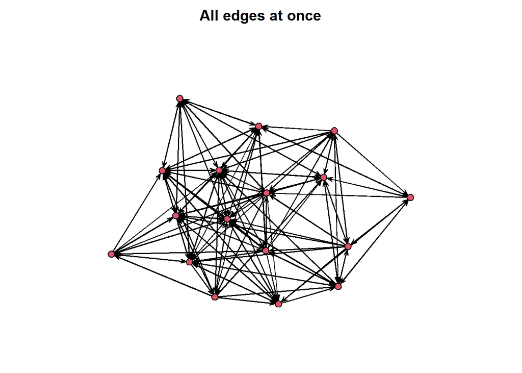

```r
par(mar = c(0,0,2,0))
plot(frat_tnet, main = "All edges at once")
```

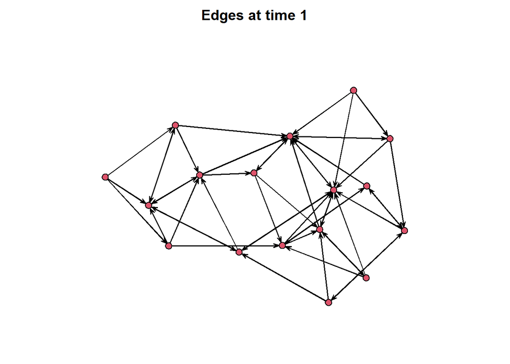

```r
plot(network.extract(frat_tnet,at=1), main = "Edges at time 1")
```

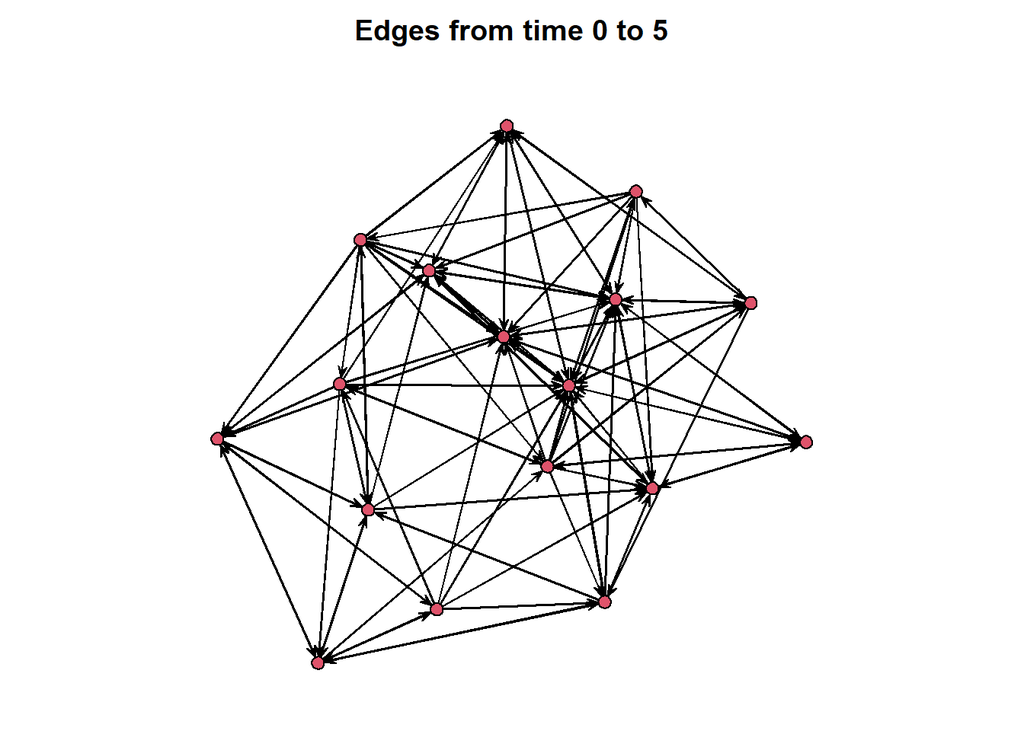

```r
plot(network.extract(frat_tnet,onset=0,terminus=5), main = "Edges from time 0 to 5")
```

### Dynamic visualization of fraternity networks

Now let’s render a dynamic movie which shows how the relationships change over time.

```r
render.d3movie(frat_tnet,output.mode = 'htmlWidget')
```

```
## slice parameters:
##   start:0
##   end:15
##   interval:1
##   aggregate.dur:1
##   rule:latest
```

[interactive chart not shown]

We can generate several other dynamic visualizations with the ndtv package. For example, below we generate a filmstrip. This function chops the timeline into 9 different slices and shows those slices side-by-side.

```r
filmstrip(frat_tnet,displaylabels=F)
```

```
## No coordinate information found in network, running compute.animation
```

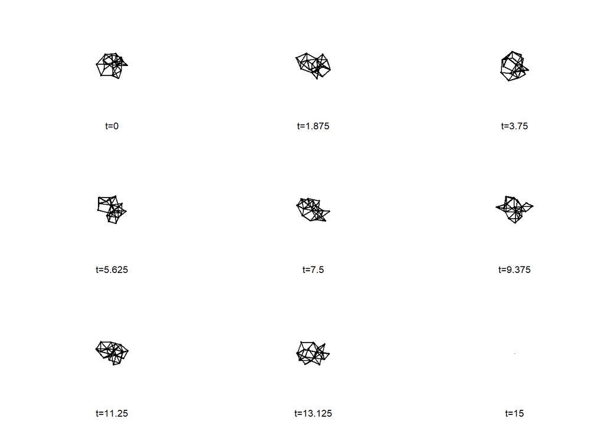

Next we can generate a time prism, which presents horizontally-layered time slices. In this case, I chose times 0, 7, and 14.

```r
compute.animation(frat_tnet)
```

```
## slice parameters:
##   start:0
##   end:15
##   interval:1
##   aggregate.dur:1
##   rule:latest
```

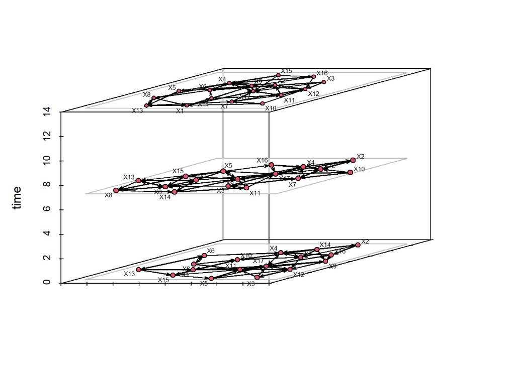

```r
timePrism(frat_tnet,at=c(0,7,14),
          displaylabels=TRUE,planes = TRUE,
          label.cex=0.5)
```

The ndtv package also allows for the visualization of timelines for each actor. The timeline below provides a sense of the stability of top-three friend relationships in this network based on the length of the lines. Short lines indicate brief friendships and long lines indicate lasting ones.

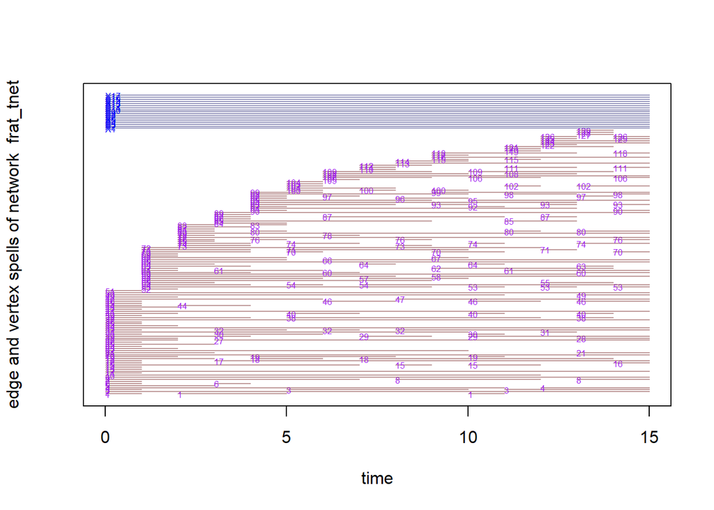

```r
timeline(frat_tnet)
```

Finally, we can generate a timeline that shows the relative closeness of the fraternity brothers as time progresses. Closeness is determined by inverse geodesic distance at each time slice. In other words, actors are closer when it takes fewer paths to get to one another. The vertical ordering of the node labels reflects similarity in social proximity across the time frame.

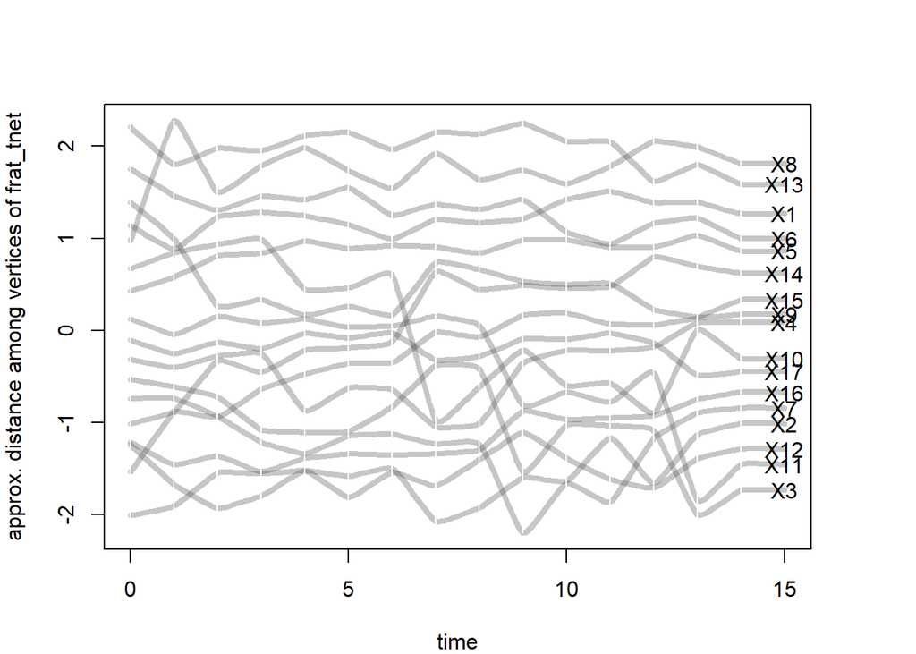

```r
par(mar = c(4,4,4,4))
proximity.timeline(frat_tnet,default.dist=6,
                   mode='sammon',labels.at=15,vertex.cex=4)
```

This timeline provides a sense of the stability of different friendships. For example, we can see that students 8 and 13 maintained close proximity throughout the semester. Other students (like student 11) appear to have explored more of the friendship space. We can also gain a sense of moments in time that involved substantial disruption in top friendship ties. The most disruption appears to have occurred right around the beginning of the semester (as students were establishing their close friendships) and also right around the time of midterm exams.

The Newcomb fraternity dataset was relatively unique during its time given the time-based component of the data. With greater access to internet and digital trace data, dynamic network data are now more readily available. These new forms of data provide even more opportunities to analyze and visualize social network dynamics.

References: Newcomb T. (1961). The acquaintance process. New York: Holt, Reinhard & Winston.